# Project_HousePrediction_Initial Data Exploration

Hyunkyung Kim

October 11, 2018

#### Import Data and Save a Copy

housedata - original data housedatac - working copy of the data

```r
housedata<-read.csv("C:\\Users\\Hyunkyung Kim\\Desktop\\CKME999\\136\\dataset\\all\\train.csv")

housedatac<-housedata
```

#### Investigating the variables.

```r
str(housedata)
```

```
## 'data.frame':    1460 obs. of  81 variables:
##  $ Id           : int  1 2 3 4 5 6 7 8 9 10 ...
##  $ MSSubClass   : int  60 20 60 70 60 50 20 60 50 190 ...
##  $ MSZoning     : Factor w/ 5 levels "C (all)","FV",..: 4 4 4 4 4 4 4 4 5 4 ...
##  $ LotFrontage  : int  65 80 68 60 84 85 75 NA 51 50 ...
##  $ LotArea      : int  8450 9600 11250 9550 14260 14115 10084 10382 6120 7420 ...
##  $ Street       : Factor w/ 2 levels "Grvl","Pave": 2 2 2 2 2 2 2 2 2 2 ...
##  $ Alley        : Factor w/ 2 levels "Grvl","Pave": NA NA NA NA NA NA NA NA NA NA ...
##  $ LotShape     : Factor w/ 4 levels "IR1","IR2","IR3",..: 4 4 1 1 1 1 4 1 4 4 ...
##  $ LandContour  : Factor w/ 4 levels "Bnk","HLS","Low",..: 4 4 4 4 4 4 4 4 4 4 ...
##  $ Utilities    : Factor w/ 2 levels "AllPub","NoSeWa": 1 1 1 1 1 1 1 1 1 1 ...
##  $ LotConfig    : Factor w/ 5 levels "Corner","CulDSac",..: 5 3 5 1 3 5 5 1 5 1 ...
##  $ LandSlope    : Factor w/ 3 levels "Gtl","Mod","Sev": 1 1 1 1 1 1 1 1 1 1 ...
##  $ Neighborhood : Factor w/ 25 levels "Blmngtn","Blueste",..: 6 25 6 7 14 12 21 17 18 4 ...
##  $ Condition1   : Factor w/ 9 levels "Artery","Feedr",..: 3 2 3 3 3 3 3 5 1 1 ...
```

[output cut: 67 more lines]

#### Checking for duplicates & uniques : Both 1460 rows - meaning No duplicate

#### Display features that has non zero N/As.

```r
nrow(housedata[,-1])
```

```
## [1] 1460
```

```r
nrow(unique(housedata[,-1]))
```

```
## [1] 1460
```

```r
NAs<-colSums(is.na(housedata))
NAs[NAs>0]
```

```
##  LotFrontage        Alley   MasVnrType   MasVnrArea     BsmtQual
##          259         1369            8            8           37
##     BsmtCond BsmtExposure BsmtFinType1 BsmtFinType2   Electrical
##           37           38           37           38            1
##  FireplaceQu   GarageType  GarageYrBlt GarageFinish   GarageQual
##          690           81           81           81           81
##   GarageCond       PoolQC        Fence  MiscFeature
##           81         1453         1179         1406
```

Number of rows = # of unique rows : no duplicate data Features that has N/As are displayed - Will work with that in the next step.

### Data Description

Checking Min/Max/quartiles for numerical, and table for categorical variables.

```r
summary(housedata)
```

```
##        Id           MSSubClass       MSZoning     LotFrontage
##  Min.   :   1.0   Min.   : 20.0   C (all):  10   Min.   : 21.00
##  1st Qu.: 365.8   1st Qu.: 20.0   FV     :  65   1st Qu.: 59.00
##  Median : 730.5   Median : 50.0   RH     :  16   Median : 69.00
##  Mean   : 730.5   Mean   : 56.9   RL     :1151   Mean   : 70.05
##  3rd Qu.:1095.2   3rd Qu.: 70.0   RM     : 218   3rd Qu.: 80.00
##  Max.   :1460.0   Max.   :190.0                  Max.   :313.00
##                                                  NA's   :259
##     LotArea        Street      Alley      LotShape  LandContour
##  Min.   :  1300   Grvl:   6   Grvl:  50   IR1:484   Bnk:  63
##  1st Qu.:  7554   Pave:1454   Pave:  41   IR2: 41   HLS:  50
##  Median :  9478               NA's:1369   IR3: 10   Low:  36
##  Mean   : 10517                           Reg:925   Lvl:1311
##  3rd Qu.: 11602
##  Max.   :215245
##
##   Utilities      LotConfig    LandSlope   Neighborhood   Condition1
##  AllPub:1459   Corner : 263   Gtl:1382   NAmes  :225   Norm   :1260
##  NoSeWa:   1   CulDSac:  94   Mod:  65   CollgCr:150   Feedr  :  81
##                FR2    :  47   Sev:  13   OldTown:113   Artery :  48
##                FR3    :   4              Edwards:100   RRAn   :  26
##                Inside :1052              Somerst: 86   PosN   :  19
##                                          Gilbert: 79   RRAe   :  11
##                                          (Other):707   (Other):  15
##    Condition2     BldgType      HouseStyle   OverallQual
##  Norm   :1445   1Fam  :1220   1Story :726   Min.   : 1.000
##  Feedr  :   6   2fmCon:  31   2Story :445   1st Qu.: 5.000
##  Artery :   2   Duplex:  52   1.5Fin :154   Median : 6.000
##  PosN   :   2   Twnhs :  43   SLvl   : 65   Mean   : 6.099
##  RRNn   :   2   TwnhsE: 114   SFoyer : 37   3rd Qu.: 7.000
##  PosA   :   1                 1.5Unf : 14   Max.   :10.000
##  (Other):   2                 (Other): 19
##   OverallCond      YearBuilt     YearRemodAdd    RoofStyle
##  Min.   :1.000   Min.   :1872   Min.   :1950   Flat   :  13
##  1st Qu.:5.000   1st Qu.:1954   1st Qu.:1967   Gable  :1141
##  Median :5.000   Median :1973   Median :1994   Gambrel:  11
##  Mean   :5.575   Mean   :1971   Mean   :1985   Hip    : 286
##  3rd Qu.:6.000   3rd Qu.:2000   3rd Qu.:2004   Mansard:   7
##  Max.   :9.000   Max.   :2010   Max.   :2010   Shed   :   2
##
```

[output cut: 89 more lines]

```
##  GdPrv:  59   Gar2:   2   Min.   :    0.00   Min.   : 1.000
##  GdWo :  54   Othr:   2   1st Qu.:    0.00   1st Qu.: 5.000
##  MnPrv: 157   Shed:  49   Median :    0.00   Median : 6.000
##  MnWw :  11   TenC:   1   Mean   :   43.49   Mean   : 6.322
##  NA's :1179   NA's:1406   3rd Qu.:    0.00   3rd Qu.: 8.000
##                           Max.   :15500.00   Max.   :12.000
##
##      YrSold        SaleType    SaleCondition    SalePrice
##  Min.   :2006   WD     :1267   Abnorml: 101   Min.   : 34900
##  1st Qu.:2007   New    : 122   AdjLand:   4   1st Qu.:129975
##  Median :2008   COD    :  43   Alloca :  12   Median :163000
##  Mean   :2008   ConLD  :   9   Family :  20   Mean   :180921
##  3rd Qu.:2009   ConLI  :   5   Normal :1198   3rd Qu.:214000
##  Max.   :2010   ConLw  :   5   Partial: 125   Max.   :755000
##                 (Other):   9
```

### Data Visualization & basic transformation

Before this, going to do some very basic data cleaning

#### CLEANING DATA

1. Remove ID ID is not really relative data here. It just identifies the rows.

```r
housedatac<-select(housedatac, -c(Id))
```

2.. MSSubClass to factor. MSSubclass is actually categorical - represented as numeric. Need to change to factor.

```r
housedatac$MSSubClass<-as.factor(housedatac$MSSubClass)
```

MSSubClass: Identifies the type of dwelling involved in the sale.

- 20 1-STORY 1946 & NEWER ALL STYLES
- 30 1-STORY 1945 & OLDER
- 40 1-STORY W/FINISHED ATTIC ALL AGES
- 45 1-1/2 STORY - UNFINISHED ALL AGES
- 50 1-1/2 STORY FINISHED ALL AGES
- 60 2-STORY 1946 & NEWER
- 70 2-STORY 1945 & OLDER
- 75 2-1/2 STORY ALL AGES
- 80 SPLIT OR MULTI-LEVEL
- 85 SPLIT FOYER
- 90 DUPLEX - ALL STYLES AND AGES
- 120 1-STORY PUD (Planned Unit Development) - 1946 & NEWER
- 150 1-1/2 STORY PUD - ALL AGES
- 160 2-STORY PUD - 1946 & NEWER
- 180 PUD - MULTILEVEL - INCL SPLIT LEV/FOYER
- 190 2 FAMILY CONVERSION - ALL STYLES AND AGES
3. Dividing into numerical and categorical columns to visualize some data.
- Numeric

```r
# Numerical into nums
nums <- unlist(lapply(housedatac, is.numeric))
housedata_num<-housedatac[ , nums]

colnames(housedata_num)
```

```
##  [1] "LotFrontage"   "LotArea"       "OverallQual"   "OverallCond"
##  [5] "YearBuilt"     "YearRemodAdd"  "MasVnrArea"    "BsmtFinSF1"
##  [9] "BsmtFinSF2"    "BsmtUnfSF"     "TotalBsmtSF"   "X1stFlrSF"
## [13] "X2ndFlrSF"     "LowQualFinSF"  "GrLivArea"     "BsmtFullBath"
## [17] "BsmtHalfBath"  "FullBath"      "HalfBath"      "BedroomAbvGr"
## [21] "KitchenAbvGr"  "TotRmsAbvGrd"  "Fireplaces"    "GarageYrBlt"
## [25] "GarageCars"    "GarageArea"    "WoodDeckSF"    "OpenPorchSF"
## [29] "EnclosedPorch" "X3SsnPorch"    "ScreenPorch"   "PoolArea"
## [33] "MiscVal"       "MoSold"        "YrSold"        "SalePrice"
```

- Categorical

```r
# Categorical into cat.

cats <-unlist(lapply(housedatac,is.factor))
housedata_cat<-housedatac[,cats]


colnames(housedata_cat)
```

```
##  [1] "MSSubClass"    "MSZoning"      "Street"        "Alley"
##  [5] "LotShape"      "LandContour"   "Utilities"     "LotConfig"
##  [9] "LandSlope"     "Neighborhood"  "Condition1"    "Condition2"
## [13] "BldgType"      "HouseStyle"    "RoofStyle"     "RoofMatl"
## [17] "Exterior1st"   "Exterior2nd"   "MasVnrType"    "ExterQual"
## [21] "ExterCond"     "Foundation"    "BsmtQual"      "BsmtCond"
## [25] "BsmtExposure"  "BsmtFinType1"  "BsmtFinType2"  "Heating"
## [29] "HeatingQC"     "CentralAir"    "Electrical"    "KitchenQual"
## [33] "Functional"    "FireplaceQu"   "GarageType"    "GarageFinish"
## [37] "GarageQual"    "GarageCond"    "PavedDrive"    "PoolQC"
## [41] "Fence"         "MiscFeature"   "SaleType"      "SaleCondition"
```

In step2, will go through ordinal variables and make some changes to this structure.

### Plot numerical - Histogram

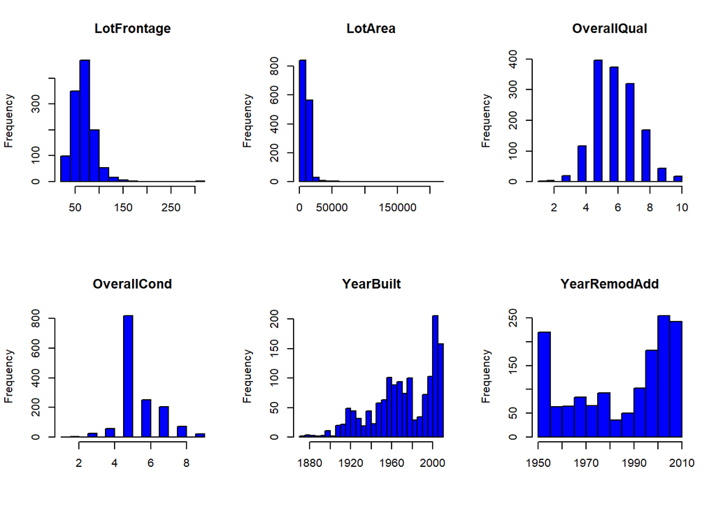

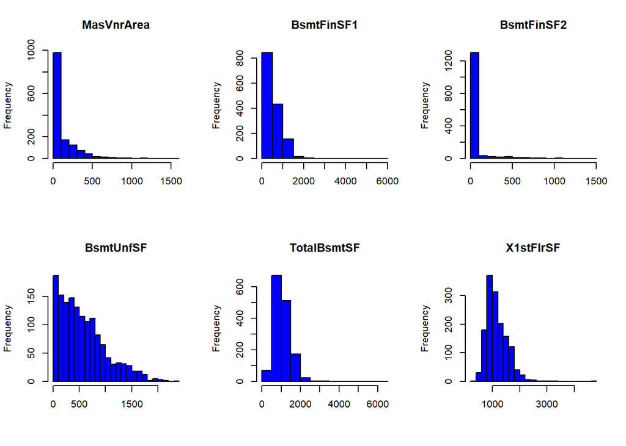

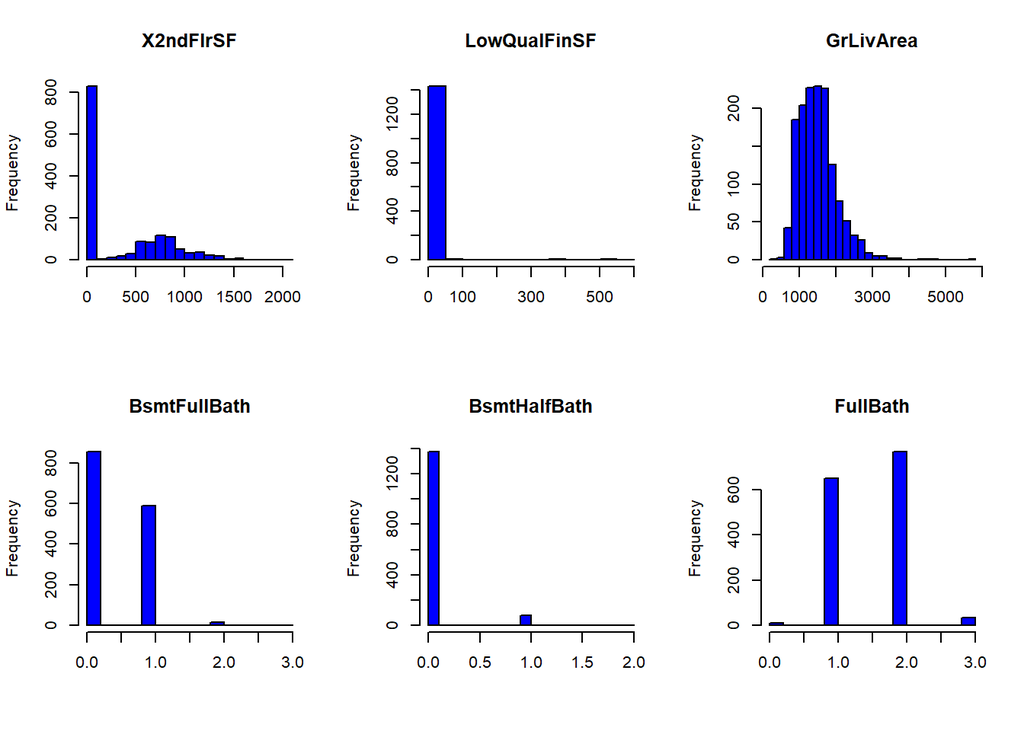

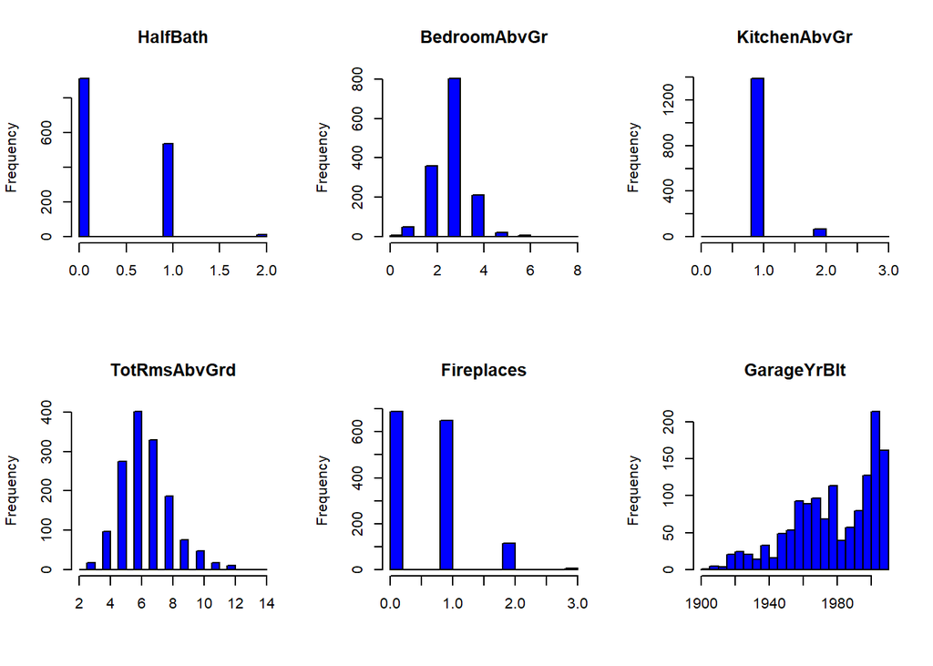

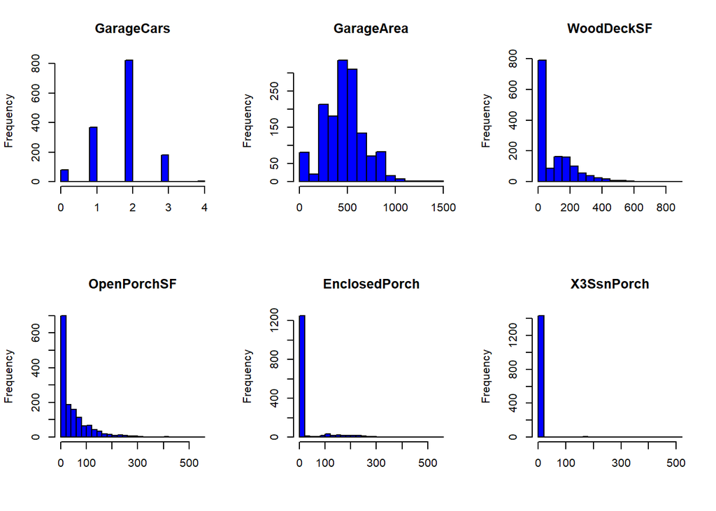

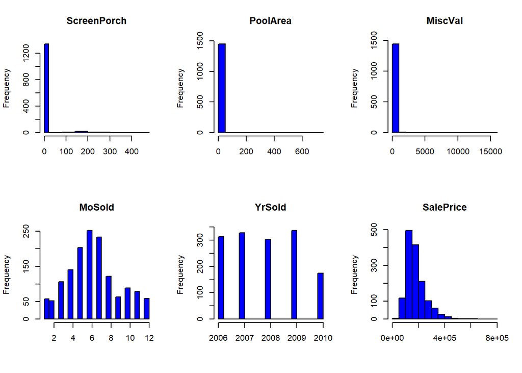

[output not shown]

[output cut: 29 more lines]

[output not shown]

```r
#sapply(housedata_num, hist,main=colnames(housedata_num), )
par(mfrow=c(2,3))
mapply(hist,as.data.frame(housedata_num),main=colnames(housedata_num),xlab='' ,breaks=20, col="blue")
```

Many of the distributions are skewed - including salePrice Log transformation would be beneficial.

### Skewness Test

Originally used Shapiro wilk test, but this only works well with n<50 and thus all my distributions showed as not-normal. Skewness - between -0.5 to 0.5 normal, absolute value between 0.5 and 1 moderately skewed. Abs value above 1 is highly skewed. Kurtosis - Kurtosis tells you the height and sharpness of the central peak, relative to that of a standard bell curve.

```r
#skewness.test(housedata_num$SalePrice)
Check<-describe(housedata_num)[,c(11,12)]
Check
```

```
##                skew kurtosis
## LotFrontage    2.16    17.34
## LotArea       12.18   202.26
## OverallQual    0.22     0.09
## OverallCond    0.69     1.09
## YearBuilt     -0.61    -0.45
## YearRemodAdd  -0.50    -1.27
## MasVnrArea     2.66    10.03
## BsmtFinSF1     1.68    11.06
## BsmtFinSF2     4.25    20.01
## BsmtUnfSF      0.92     0.46
## TotalBsmtSF    1.52    13.18
## X1stFlrSF      1.37     5.71
## X2ndFlrSF      0.81    -0.56
## LowQualFinSF   8.99    82.83
## GrLivArea      1.36     4.86
## BsmtFullBath   0.59    -0.84
## BsmtHalfBath   4.09    16.31
## FullBath       0.04    -0.86
## HalfBath       0.67    -1.08
## BedroomAbvGr   0.21     2.21
## KitchenAbvGr   4.48    21.42
## TotRmsAbvGrd   0.67     0.87
## Fireplaces     0.65    -0.22
## GarageYrBlt   -0.65    -0.42
## GarageCars    -0.34     0.21
## GarageArea     0.18     0.90
## WoodDeckSF     1.54     2.97
## OpenPorchSF    2.36     8.44
## EnclosedPorch  3.08    10.37
## X3SsnPorch    10.28   123.06
## ScreenPorch    4.11    18.34
## PoolArea      14.80   222.19
## MiscVal       24.43   697.64
## MoSold         0.21    -0.41
## YrSold         0.10    -1.19
## SalePrice      1.88     6.50
```

Below items all high skewness and may need transformation.

- LotFrontage 2.16 17.34
- LotArea 12.18 202.26
- MasVnrArea 2.66 10.03
- BsmtFinSF1 1.68 11.06
- BsmtFinSF2 4.25 20.01
- TotalBsmtSF 1.52 13.18
- X1stFlrSF 1.37 5.71
- LowQualFinSF 8.99 82.83
- GrLivArea 1.36 4.86
- BsmtHalfBath 4.09 16.31
- KitchenAbvGr 4.48 21.42
- OpenPorchSF 2.36 8.44
- EnclosedPorch 3.08 10.37
- X3SsnPorch 10.28 123.06
- ScreenPorch 4.11 18.34
- PoolArea 14.80 222.19
- MiscVal 24.43 697.64
- SalePrice 1.88 6.50

#### Subset non-normal variables.

```r
H_SkewedVar<-select(housedata_num,c(


LotArea,
MasVnrArea,
BsmtFinSF1,
BsmtFinSF2,
TotalBsmtSF,
X1stFlrSF,
LowQualFinSF,
GrLivArea,
BsmtHalfBath,
KitchenAbvGr,
OpenPorchSF,
EnclosedPorch,
X3SsnPorch,
ScreenPorch,
PoolArea,
MiscVal,
SalePrice))
```

#### Apply Log base 10 and check skewness.

(log10(x+1) because there are some x=0 values)

```r
describe(H_SkewedVar)[,c(11,12)]
```

```
##                skew kurtosis
## LotArea       12.18   202.26
## MasVnrArea     2.66    10.03
## BsmtFinSF1     1.68    11.06
## BsmtFinSF2     4.25    20.01
## TotalBsmtSF    1.52    13.18
## X1stFlrSF      1.37     5.71
## LowQualFinSF   8.99    82.83
## GrLivArea      1.36     4.86
## BsmtHalfBath   4.09    16.31
## KitchenAbvGr   4.48    21.42
## OpenPorchSF    2.36     8.44
## EnclosedPorch  3.08    10.37
## X3SsnPorch    10.28   123.06
## ScreenPorch    4.11    18.34
## PoolArea      14.80   222.19
## MiscVal       24.43   697.64
## SalePrice      1.88     6.50
```

```r
describe(log10(H_SkewedVar+1),)[,c(11,12)]
```

```
##                skew kurtosis
## LotArea       -0.14     4.68
## MasVnrArea     0.49    -1.63
## BsmtFinSF1    -0.62    -1.48
## BsmtFinSF2     2.52     4.52
## TotalBsmtSF   -5.14    27.60
## X1stFlrSF      0.08     0.14
## LowQualFinSF   7.44    54.12
## GrLivArea     -0.01     0.27
## BsmtHalfBath   3.92    13.78
## KitchenAbvGr   3.86    19.95
## OpenPorchSF   -0.02    -1.78
## EnclosedPorch  2.11     2.55
## X3SsnPorch     7.72    58.13
## ScreenPorch    3.14     7.98
## PoolArea      14.33   203.69
## MiscVal        5.16    25.31
## SalePrice      0.12     0.80
```

The Log transformation significantly improved skewness for below.

```
           skew kurtosis
```

- LotArea -0.14 4.68
- MasVnrArea 0.49 -1.63
- BsmtFinSF1 -0.62 -1.48
- BsmtFinSF2 2.52 4.52
- X1stFlrSF 0.08 0.14
- GrLivArea -0.01 0.27
- OpenPorchSF -0.02 -1.78
- SalePrice 0.12 0.80

#### Plot Histogram to see if this matches with the skewness changes.

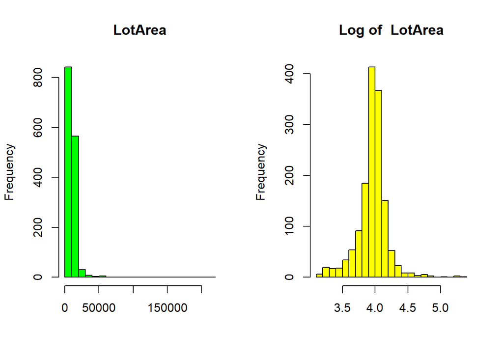

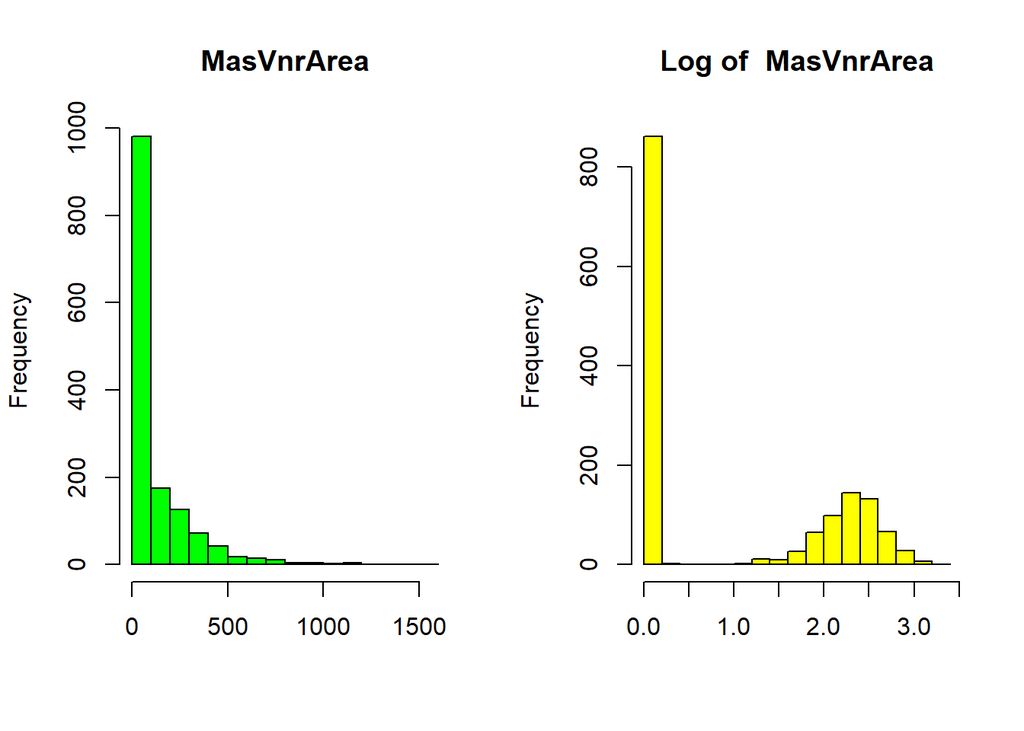

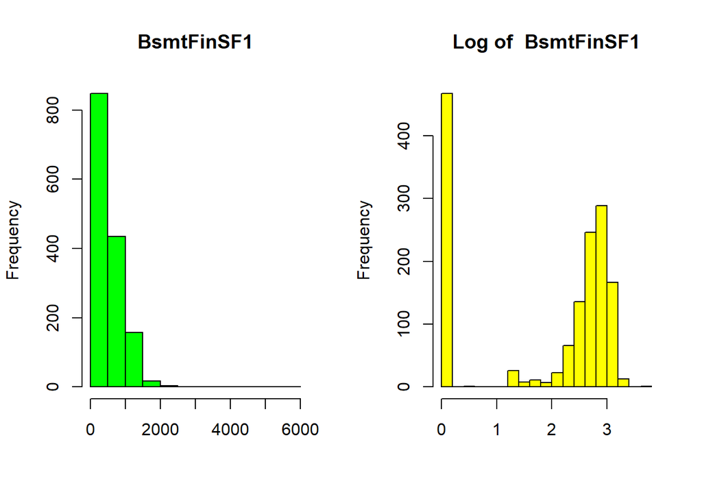

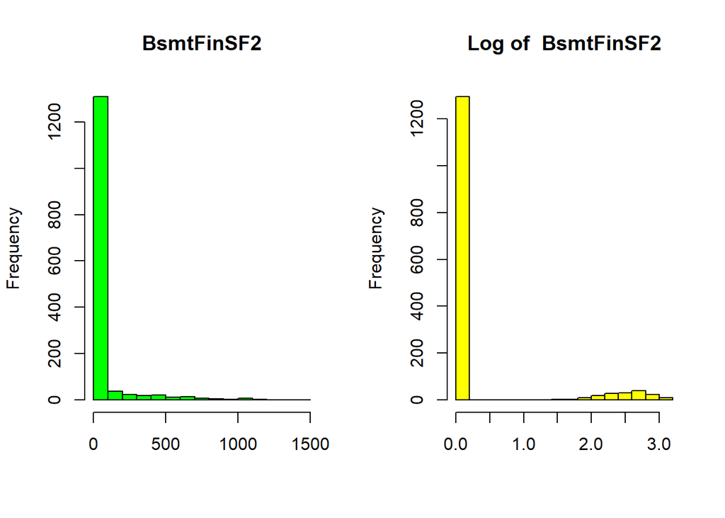

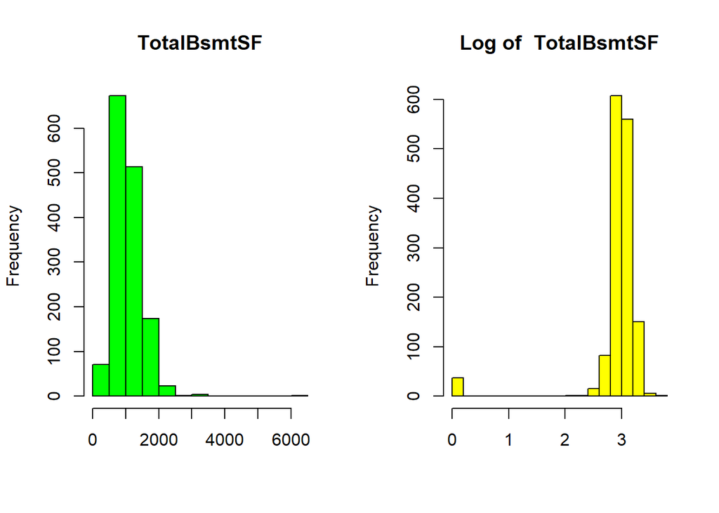

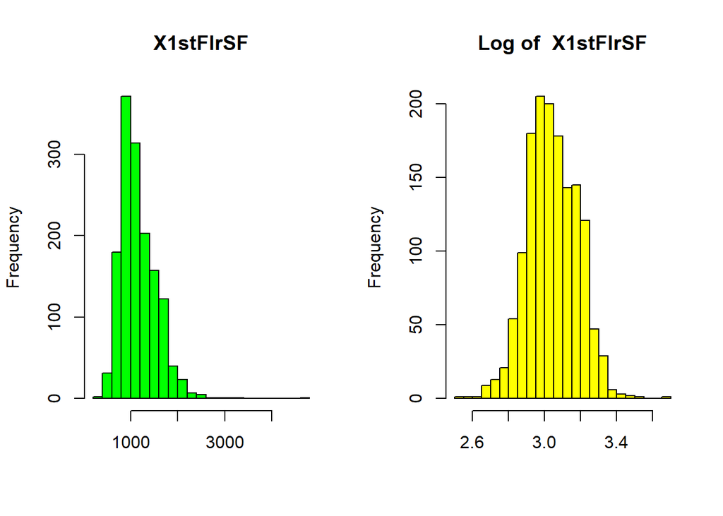

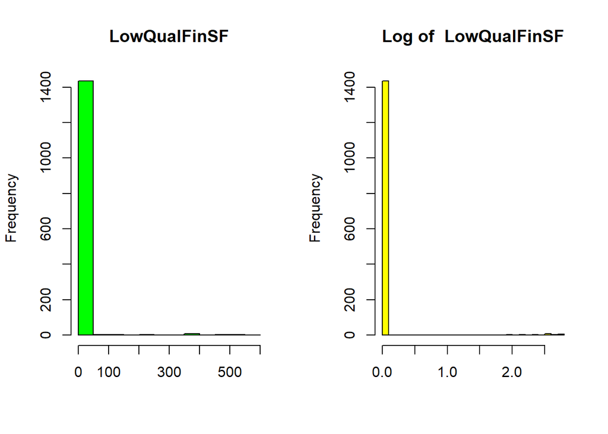

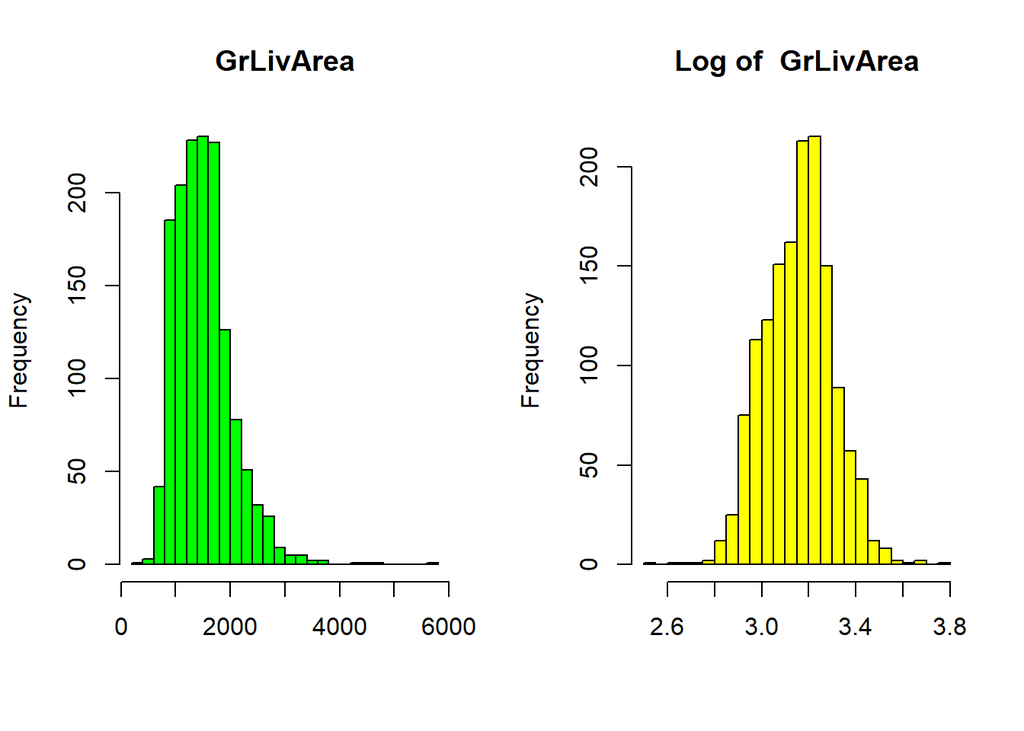

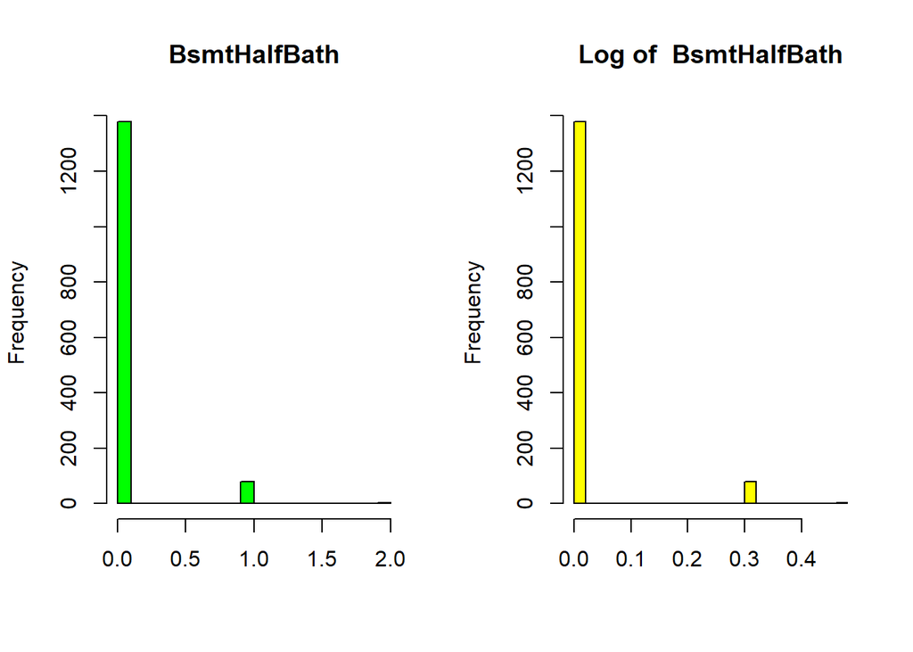

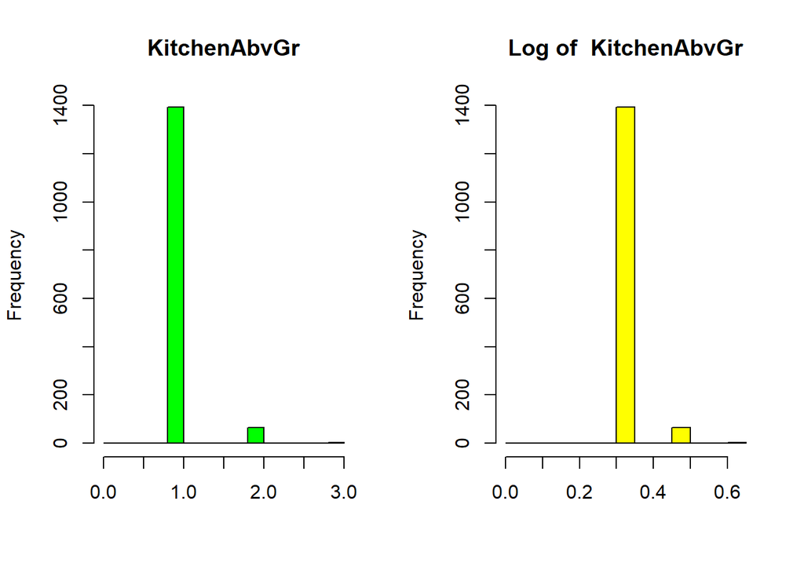

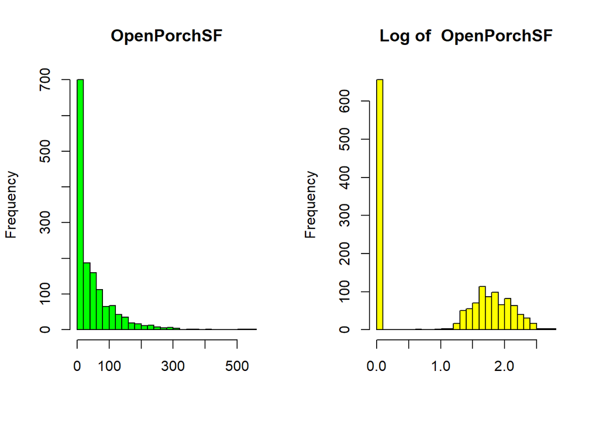

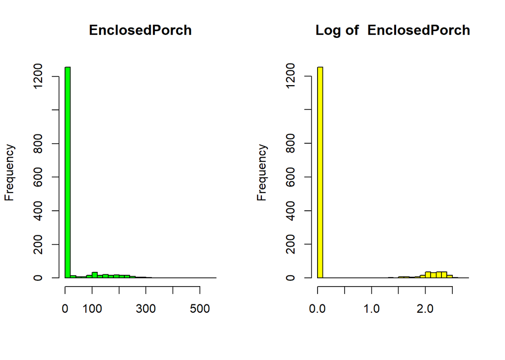

[5 more figures not shown]

```r
par(mfrow=c(1,2))
for (i in 1:17){
hist(H_SkewedVar[,i],main=colnames(H_SkewedVar[i]),xlab='' ,breaks=20, col="green")
#  lines(density(H_SkewedVar[,i], na.rm=T),col="green")
hist(log10(H_SkewedVar[,i]+1),main=paste("Log of ",colnames(H_SkewedVar[i])),xlab='' ,breaks=20, col="yellow")
# lines(density(log10(H_SkewedVar[,i]), na.rm=T),col="yellow")
}
```

Looks like it matches with the skewness values.

```
           skew kurtosis
```

LotArea -0.14 4.68 MasVnrArea 0.49 -1.63 BsmtFinSF1 -0.62 -1.48 BsmtFinSF2 2.52 4.52 X1stFlrSF 0.08 0.14 GrLivArea -0.01 0.27 OpenPorchSF -0.02 -1.78 SalePrice 0.12 0.80

### Plot numerical 2 - Boxplot to check outliers

An outlier is defined as above 1.5 interqurtile range above the upper quartile(Q3) and below 1.5 of lower quartile(Q1). Looking at the boxplot, there are too many outliers. Many are because the distribution is skewed, and some because majority of the distribution are packed into very small range (variance is very small).

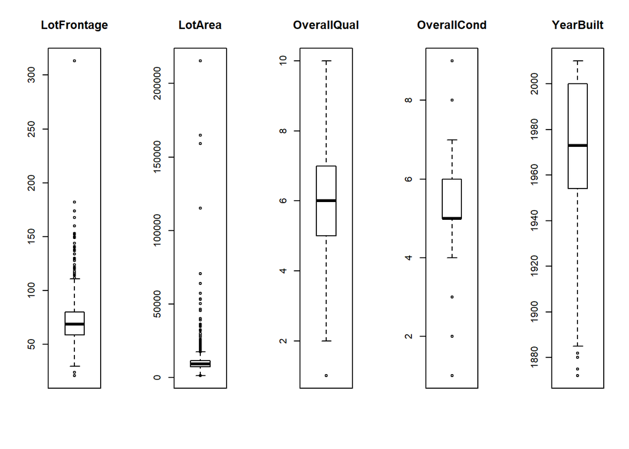

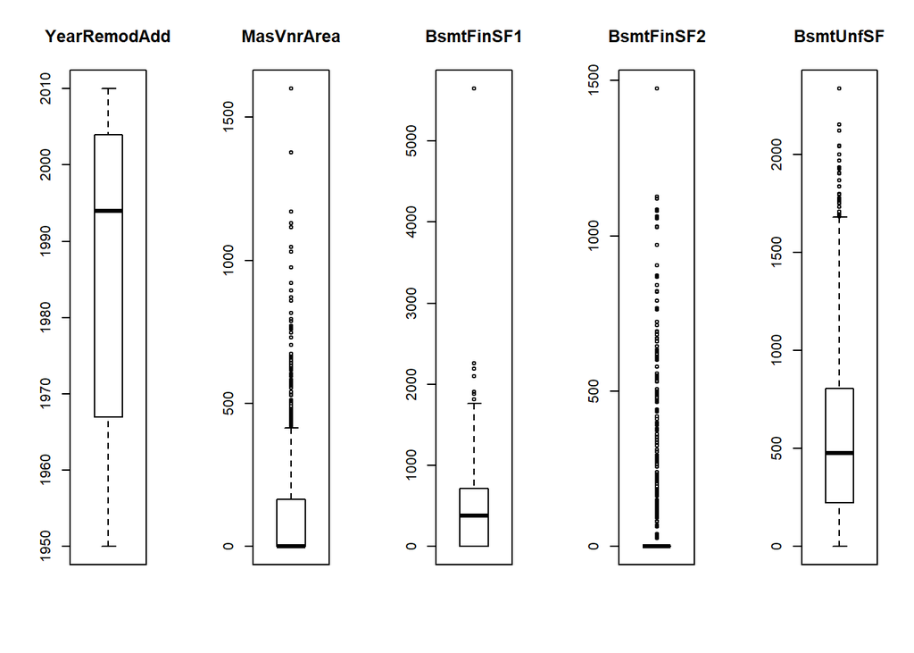

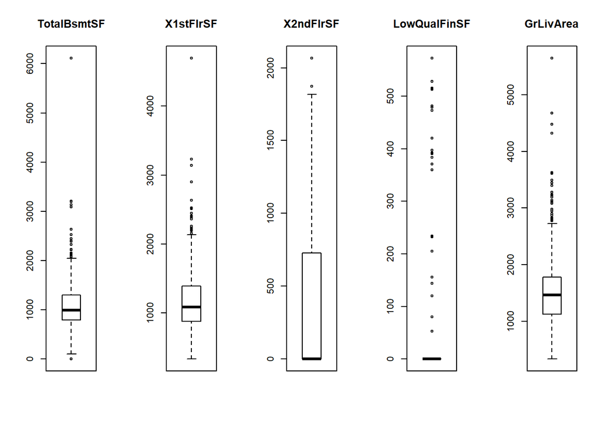

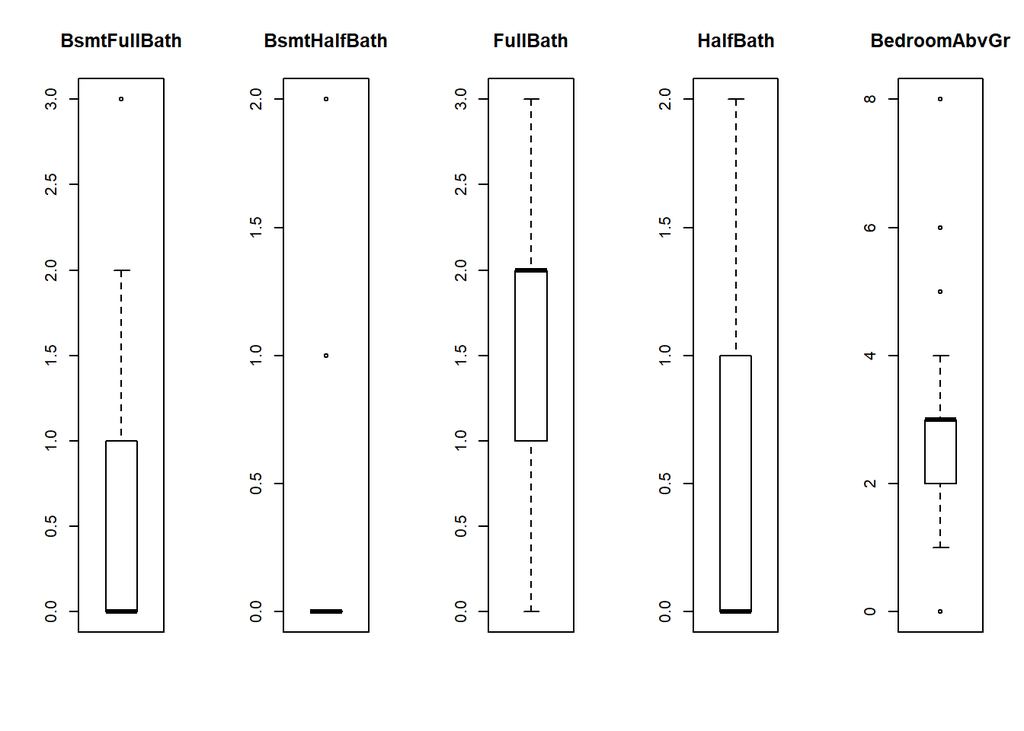

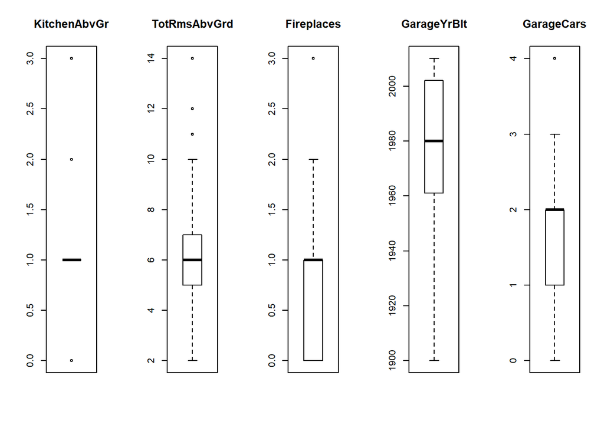

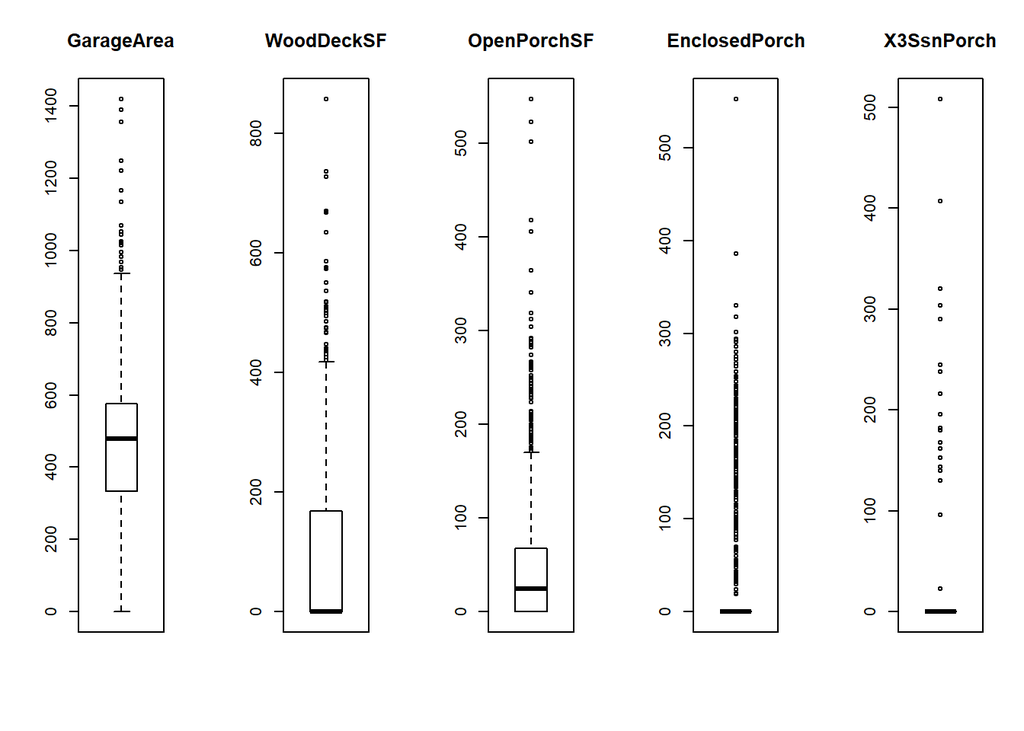

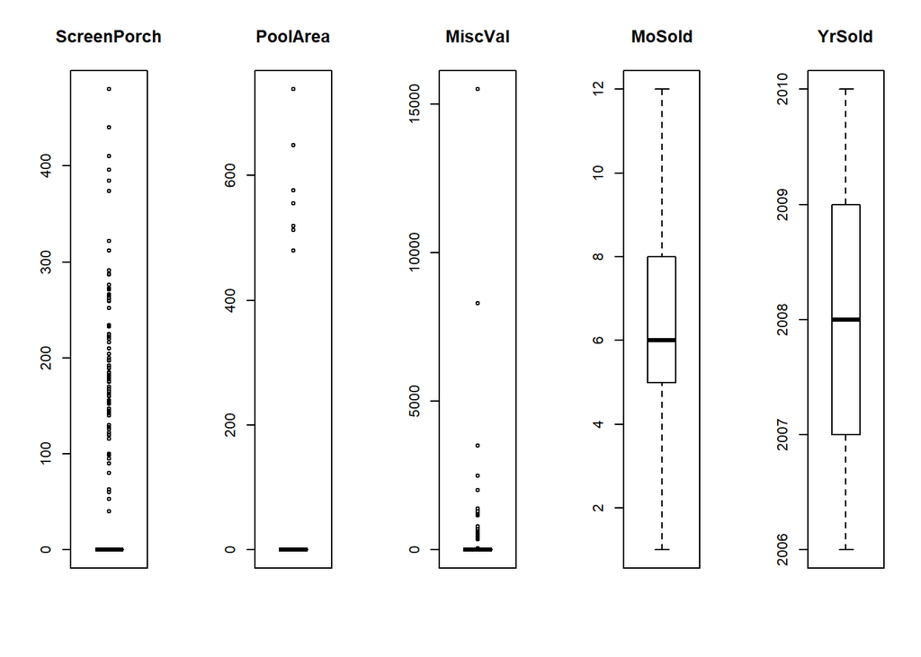

[output not shown]

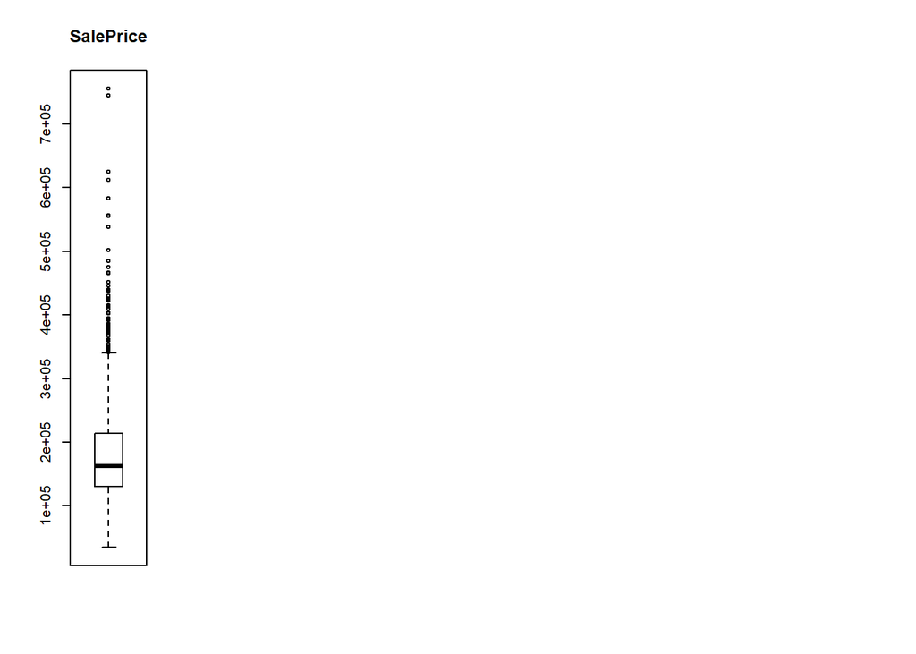

```r
par(mfrow=c(1,5))


# The mapply() function stands for 'multivariate' apply. Its purpose is to be able to vectorize arguments to a function that is not usually accepting vectors as arguments. In short, mapply() applies a Function to Multiple List or multiple Vector Arguments.

mapply(boxplot,data.frame(housedata_num),main=colnames(housedata_num) )
```

### Print Outliers

```r
#boxplot.stats(housedata_num[,1])
for (i in 1:36)
{
(a<-boxplot.stats(housedata_num[,i]))

print(colnames(housedata_num)[i])
print(a$out)}
```

```
## [1] "LotFrontage"
##  [1] 112 115  24  21 121 122  24 120 134 141  24  24 174  21  21 174  21
## [18]  21 120 129 140 120 118 116 150  21 130  21  24  21 137  21  21  24
## [35] 130  24  21  21  21 120  24  24 144 114  24  21 128 116 149  21 313
## [52]  24  24  24 122 130 121  21 115  21  21  21 120  24  24  24 114 168
## [69] 182 134  24 120 118 138 160  24 152  21 124  21 313  24 153 120 129
## [86] 124  21  21
## [1] "LotArea"
##  [1]  50271  19900  21000  21453  19378  31770  22950  25419 159000  19296
## [11]  39104  19138  18386 215245 164660  20431  18800  53107  34650  22420
## [21]  21750  70761  53227  40094  32668  21872  21780  25095  46589  20896
## [31]  18450  21535  26178 115149  21695  53504  21384  28698  45600  17920
## [41]  25286  27650  24090  25000   1300  21286  21750  29959  18000  23257
## [51]  17755  35760  18030  35133  32463  18890  24682  23595  17871  36500
## [61]  63887  20781  25339  57200  20544  19690  21930  26142
```

[output cut: 137 more lines]

Looking through these values, most of them looks to be biproduct of skewed distribution or extremely small variance. Will look this into a little more after cleaning up the data using cook’s distance.

### Check to see relationship with response variable - house price VS ind. variables.